# Data Incubator Proposal: Natural Language Processing, Plot 2

This is a plot of the 20 most frequent bigrams in a 10,000-row subset of a dataset of Tweets, with common stop words filtered out. It is a continuation of the information given on “Data Incubator Proposal: Natural Language Processing, Plot 1”.  
I will be using the “tm” and “RWeka” R packages, as they contain a lot of useful tools for this purpose.

```r
suppressMessages(library(tm))
suppressMessages(library(RWeka))
```

```r
suppressMessages(library(ggplot2))
```

As before, due to the size of the dataset (77.6 Mb zipped, 227 Mb unzipped) I am pre-loading a 10,000 subsample to GitHub, which this code will be running on. The full set can be found here: http://help.sentiment140.com/for-students/. I would use this code to download the full set from the internet:

```r
fileUrl <- "http://cs.stanford.edu/people/alecmgo/trainingandtestdata.zip"
temp <- tempfile()
download.file(fileUrl, destfile = temp, mode = "wb")
unzip(temp, "training.1600000.processed.noemoticon.csv")
tweets <- read.csv("training.1600000.processed.noemoticon.csv", header = FALSE, nrows = 10000)
unlink(temp)
```

I will be using this code instead to load the data subset:

```r
fileUrl <- "https://raw.githubusercontent.com/amontgom/DataIncubatorProjectProposal/master/tweets.csv"
temp <- tempfile()
download.file(fileUrl, destfile = temp, mode = "wb")
tweets <- read.csv(temp, header = FALSE, nrows = 10000)
unlink(temp)
```

The following is some Preprocessing for the set of Tweets, including: extracting the tweets specifically, transforming the data into a Corpus, and altering various data, like changing capitalization, making all letters lower-case, stripping white space, and removing stop words.

```r
tweetsOnly <- tweets$V6
corp <- Corpus(VectorSource(tweetsOnly))
space  <- content_transformer(function(x, pattern) gsub(pattern, " ", x))
corp <- tm_map(corp, space,"\"|/|@|\\|")
corp <- tm_map(corp, content_transformer(tolower))
corp <- tm_map(corp, removeNumbers)
corp <- tm_map(corp, stripWhitespace)
corp <- tm_map(corp, removeWords, stopwords('english'))
```

Here, I shift the Corpus back into a dataframe, tokenize the data, and create my subset of bigrams, in this case the first 100 most popular word pairs that aren’t stop words.

```r
corpDF <- data.frame(text = unlist(corp), stringsAsFactors = FALSE)
tokens <- NGramTokenizer(corpDF, Weka_control(min = 2, max = 2, delimiters = " \\r\\n\\t.,;:\"()?!"))
tokens <- data.frame(table(tokens))
biGram <- tokens[order(tokens$Freq, decreasing = TRUE),][1:100,]
colnames(biGram) <- c("words","count")
```

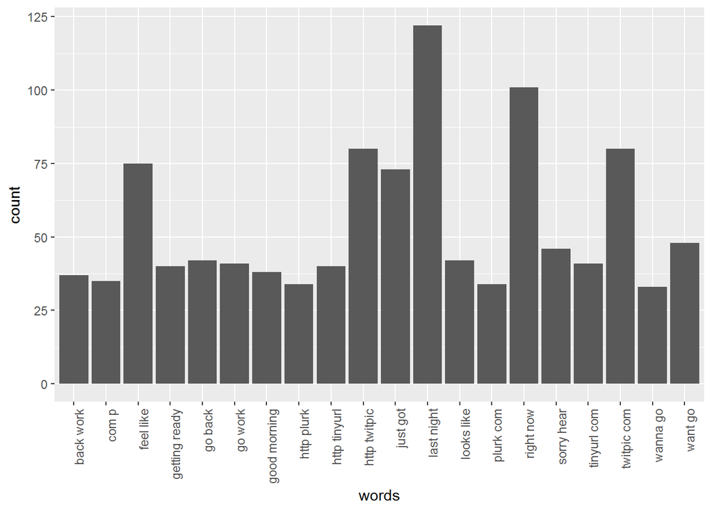

```r
ggplot(biGram[1:20,], aes(words, count)) + geom_bar(stat = "identity") +
    theme(axis.text.x = element_text(angle = 90, hjust = 1))
```

The next step would be to further process out things like urls, the creation of trigrams (no point going deeper than that, though), and finally the application of machine-learning software to try to figure out what people are most likely to type next.